# Lab 5

## Joe’s Diet Simulation

This is a simulation of a finite state Markov chain.

1. Simulate N steps. Start in state j0.

```r
(PJ = matrix(c(0,0,.2,1,.5,0,0,.5,.8), ncol = 3))
```

```
##      [,1] [,2] [,3]
## [1,]  0.0  1.0  0.0
## [2,]  0.0  0.5  0.5
## [3,]  0.2  0.0  0.8
```

```r
rowSums(PJ)
```

```
## [1] 1 1 1
```

```r
N <- 1000
j0 = 1
states <- c(j0,rep(NA,N))

for (j in 1:N){
  states[j+1] <- sample(3,1,prob = PJ[states[j],])
}

head(states,10) #10 days
```

```
##  [1] 1 2 3 3 3 3 3 3 3 1
```

```r
table(states) #for 1000 days
```

```
## states
##   1   2   3
## 131 259 611
```

```r
(PJ%*%PJ%*%PJ)[2,3]
```

```
## [1] 0.645
```

## Roulette Simulation

- Bet $1, always on RED. Play until the money is gone.
1. **How many games do we expect to play?**

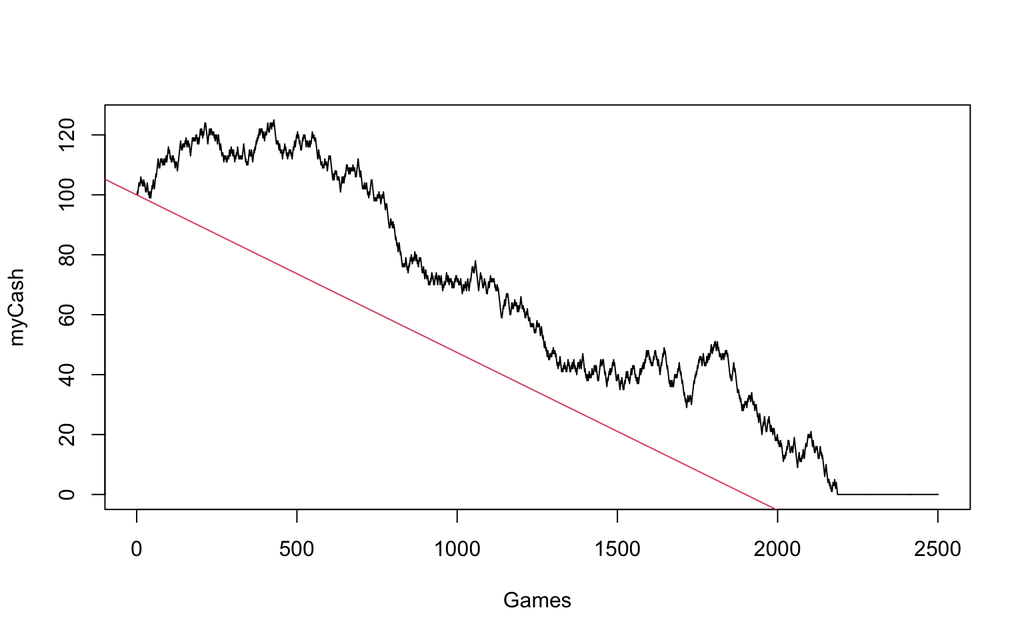

```r
p = 18/38   # probability of winning
X0 = 100    # initial amount
N = 2500    # maximal number of spins

myCash = c(X0, rep(0,N)) # vector for my cash

spins <- rbinom(N,1,p) # simulate  N  spins ,from a bernoulli distribution-->0 or 1;loose or win

counter  = 1

while(myCash[counter] > 0 & counter <= N){ #this goes on until I loose all my money and reaches the maximal number of spins
  myCash[counter + 1] <- myCash[counter] + 2*spins[counter] -1
  counter <- counter + 1
}

plot(myCash, type = 'l',xlab = "Games")            # plot of my cash
abline(a = X0, b = -1/19, col = 2)  # plot expected trend
```

2. Make 10 simulations and plot them,

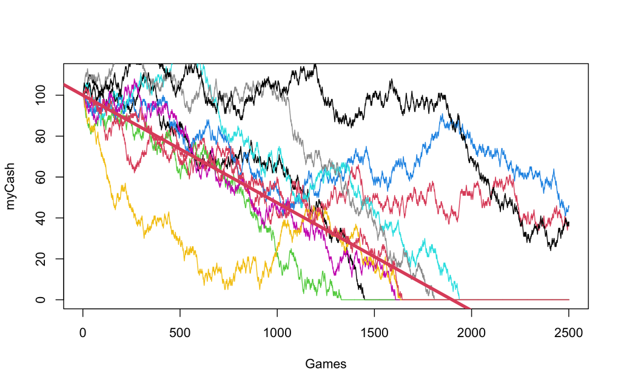

```r
myCash = c(X0, rep(0,N)) # vector for my cash
spins <- rbinom(N,1,p) # simulate 1000 spins
counter  = 1
while(myCash[counter] > 0 & counter <= N){
  myCash[counter + 1] <- myCash[counter] + 2*spins[counter] -1
  counter <- counter + 1
}
plot(myCash, type = 'l',xlab="Games")            # plot of my cash

for (j in 2:10){
  myCash = c(X0, rep(0,N)) # vector for my cash

spins <- rbinom(N,1,p) # simulate  N  spins
counter  = 1
while(myCash[counter] > 0 & counter <= N){
  myCash[counter + 1] <- myCash[counter] + 2*spins[counter] -1
  counter <- counter + 1
}
lines(myCash, col = j)            # plot of my cash
}
abline(a = X0, b = -1/19, col = 2, lwd = 4)  # plot expected trend
```

2. What is the expected time until we go bankrupt?

Make 1000 simulations and record the time when the money runs out in each case.

```r
N = 2500
times = rep(0,1000)

# simulate repeating 1000 experiments

for (j in 1:1000){

  myCash = c(X0, rep(0,N)) # vector for my cash
spins <- rbinom(N,1,p) # simulate N spins-->bernoulli 1 or 0
counter  = 1

while(myCash[counter] > 0 & counter <= N){

  myCash[counter + 1] <- myCash[counter] + 2*spins[counter] -1
  counter <- counter + 1
}

# when j=1 the whole experiment runs and will record  the counter where it hit 0.
# counter is index on mycash

times[j] <- counter #this would be the time that I loose all my money
}

paste("Mean time = ",round(mean(times),0))
```

```
## [1] "Mean time =  1772"
```

## St. Petersburg System

- Starting bet $1, always on RED. Double after each loss if possible.
- Play until the money is gone.
- Repeat this a number of times.

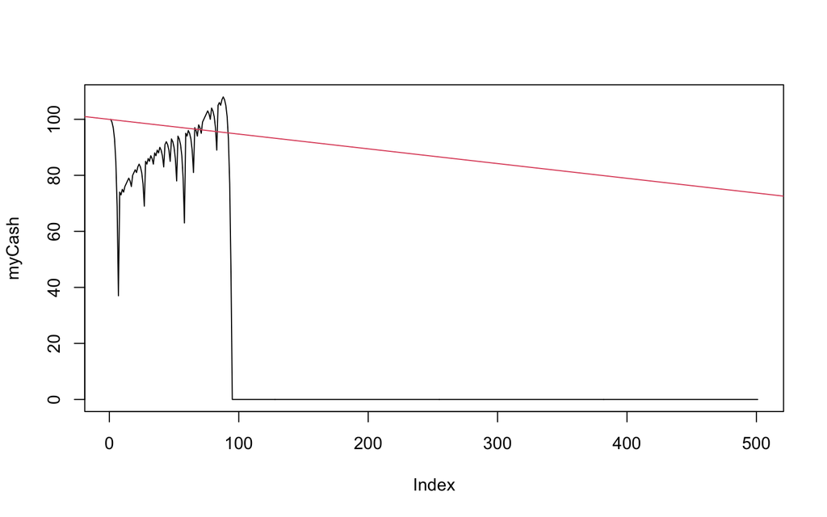

```r
set.seed(124)
p = 18/38   # probability of winning
X0 = 100    # initial amount
N = 500    # maximal number of spins

myCash = c(X0, rep(0,N)) # vector for my cash

spins <- rbinom(N,1,p) # simulate  N  spins

counter  = 1  # keep track of number of games

lastspin = 1  # initialize memory of last games

myBet = 1

while(myCash[counter] > 0 & counter <= N){
  #this goes on until I loose all my money or reaches the maximal number of spins

  myBet <- min(c(2*myBet,myCash[counter])) #bet is double down if loose

  if(lastspin == 1){myBet <- 1} #if win bet is $1

  myCash[counter + 1] <- myCash[counter] + (2*spins[counter] - 1)*myBet
  lastspin <- spins[counter]
  counter <- counter + 1
}

plot(myCash, type = 'l')            # plot of my cash
abline(a = X0, b = -1/19, col = 2)  # plot expected trend
```

**What is happening? Tell the story. Then try again.**

Redo with house limit (maximal bet).

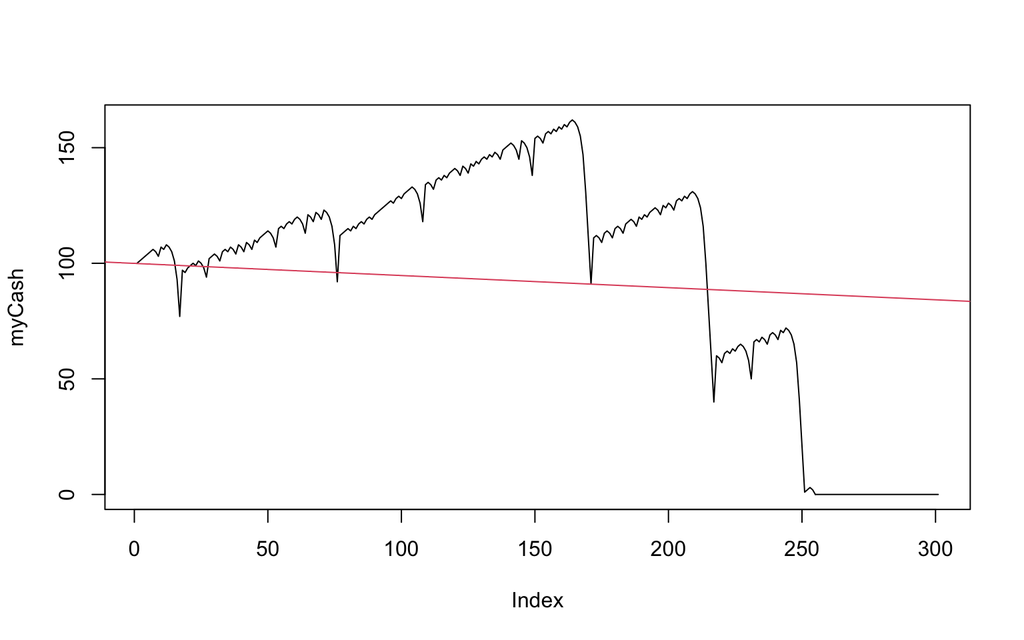

```r
set.seed(128)
p = 18/38   # probability of winning
maxBet = 20     # maximal bet
X0 = 100    # initial amount
N = 300    # maximal number of spins
myCash = c(X0, rep(0,N)) # vector for my cash

spins <- rbinom(N,1,p) # simulate  N  spins
counter  = 1  # keep track of number of games
lastspin = 1  # initialize memory of last games
myBet = 1

while(myCash[counter] > 0 & counter <= N){
  myBet <- min(c(2*myBet,myCash[counter], maxBet)) #now its either the doubled bet, last amount left with me or the maximal bet

  if(lastspin == 1){myBet <- 1}
  myCash[counter + 1] <- myCash[counter] + (2*spins[counter] - 1)*myBet
  lastspin <- spins[counter]
  counter <- counter + 1
}
plot(myCash, type = 'l')            # plot of my cash
abline(a = X0, b = -1/19, col = 2)  # plot expected trend
```

## Simulation of Cave Adventure

1. Set up transition matrix. This is a 9x9 matrix.

```r
P <- matrix(0, ncol = 9, nrow = 9)
diag(P) <- 1/2
P[1,2] <- P[1,4] <- 1/4
P[2,1] <- P[2,3] <- P[2,5] <- 1/6
P[3,2] <- P[3,6] <- 1/4
P[4,1] <- P[4,5] <- P[4,7] <- 1/6
P[5,2] <- P[5,4] <- P[5,6] <- 1/6
P[6,3] <- P[6,5] <- 1/4
P[7,4] <- P[7,8] <- 1/4
P[8,7] <- P[8,9] <- 1/4
P[9,9] <- 1
rowSums(P)
```

```
## [1] 1 1 1 1 1 1 1 1 1
```

```r
P
```

```
##            [,1]      [,2]      [,3]      [,4]      [,5]      [,6]      [,7]
##  [1,] 0.5000000 0.2500000 0.0000000 0.2500000 0.0000000 0.0000000 0.0000000
##  [2,] 0.1666667 0.5000000 0.1666667 0.0000000 0.1666667 0.0000000 0.0000000
##  [3,] 0.0000000 0.2500000 0.5000000 0.0000000 0.0000000 0.2500000 0.0000000
##  [4,] 0.1666667 0.0000000 0.0000000 0.5000000 0.1666667 0.0000000 0.1666667
##  [5,] 0.0000000 0.1666667 0.0000000 0.1666667 0.5000000 0.1666667 0.0000000
##  [6,] 0.0000000 0.0000000 0.2500000 0.0000000 0.2500000 0.5000000 0.0000000
##  [7,] 0.0000000 0.0000000 0.0000000 0.2500000 0.0000000 0.0000000 0.5000000
##  [8,] 0.0000000 0.0000000 0.0000000 0.0000000 0.0000000 0.0000000 0.2500000
##  [9,] 0.0000000 0.0000000 0.0000000 0.0000000 0.0000000 0.0000000 0.0000000
##       [,8] [,9]
##  [1,] 0.00 0.00
##  [2,] 0.00 0.00
##  [3,] 0.00 0.00
##  [4,] 0.00 0.00
##  [5,] 0.00 0.00
##  [6,] 0.00 0.00
##  [7,] 0.25 0.00
##  [8,] 0.50 0.25
##  [9,] 0.00 1.00
```

2. Let’s see what happens in 10 minutes. Simulate 10 minutes

every 1 minute is a step.

```r
steps = 10
states = rep(1,steps + 1)
for (j in 1:steps){
  states[j+1] <- sample(9,1,prob = P[states[j],])

}
print(states)
```

```
##  [1] 1 4 7 7 8 9 9 9 9 9 9
```

3. What is the probability that he is in room 3 after 2 steps if he starts with room 1?

Do this by looking at the maze.

[figure not shown]

```r
#by loooking at the maze, we can see 1-->2 -->3
(1/4)*(1/6)
```

```
## [1] 0.04166667
```

Confirm by computing a suitable power of the transition matrix.

```r
(P%*%P)[1,3] # P^2[1,3]
```

```
## [1] 0.04166667
```

4. What is the probability that he is in room 8 after 3 steps if he starts with room 1? ?

Do this by looking at the maze.

```r
#by loooking at the maze, we can see 1-->4-->7-->8
(1/6)*(1/4)*(1/4)
```

```
## [1] 0.01041667
```

Confirm by computing a suitable power of the transition matrix.

```r
(P%*%P%*%P)[1,8]
```

```
## [1] 0.01041667
```

5. What is the probability that he is in room 5 after 4 steps if he starts with room 1?

Hard to do this by looking at the maze. Compute with a suitable power of the transition matrix.

```r
(P%*%P%*%P%*%P)[1,5] #P^4[1,5]intitally he was at room 1 and now he is in room 5
```

```
## [1] 0.1461227
```

6. What is the probability that he is in room 9 after 30 steps?

```r
# function to compute matrix powers
powerP = function(A,n){
  B <- 0*A
  diag(B) <- 1  # make identity matrix
  #now B is the identity matrix, it is for initial multiplication
  #if you multiply a matrix with the identity matrix, it is the same

  for (j in 1:n){
    B <- B%*%A
    }
  return(B)
}
powerP(P,30)[1,9] #P^30
```

```
## [1] 0.219303
```

7. Compute the probability distribution of the 9 states after 30 steps if we start in `room 1`.

```r
powerP(P,30) #P^30
```

```
##             [,1]       [,2]       [,3]       [,4]       [,5]       [,6]
##  [1,] 0.09072066 0.14427732 0.09886897 0.12281737 0.14061653 0.09804868
##  [2,] 0.09618488 0.15345583 0.10538890 0.12987816 0.14944572 0.10448272
##  [3,] 0.09886897 0.15808334 0.10872982 0.13326701 0.15387168 0.10777309
##  [4,] 0.08187825 0.12987816 0.08884467 0.11108406 0.12666609 0.08813060
##  [5,] 0.09374435 0.14944572 0.10258112 0.12666609 0.14556986 0.10170729
##  [6,] 0.09804868 0.15672409 0.10777309 0.13219590 0.15256094 0.10682822
##  [7,] 0.05649721 0.08902743 0.06062397 0.07706540 0.08697173 0.06017712
##  [8,] 0.02885030 0.04522417 0.03068407 0.03952164 0.04423958 0.03047452
##  [9,] 0.00000000 0.00000000 0.00000000 0.00000000 0.00000000 0.00000000
##             [,7]       [,8]      [,9]
##  [1,] 0.05649721 0.02885030 0.2193030
##  [2,] 0.05935162 0.03014945 0.1716627
##  [3,] 0.06062397 0.03068407 0.1480980
##  [4,] 0.05137693 0.02634776 0.2957935
##  [5,] 0.05798115 0.02949305 0.1928114
##  [6,] 0.06017712 0.03047452 0.1552174
##  [7,] 0.03612734 0.01872204 0.5147878
##  [8,] 0.01872204 0.00977958 0.7525041
##  [9,] 0.00000000 0.00000000 1.0000000
```

```r
s=c(1:9)
(states =paste("From room 1 to room",s,"in 30 steps") )
```

```
## [1] "From room 1 to room 1 in 30 steps" "From room 1 to room 2 in 30 steps"
## [3] "From room 1 to room 3 in 30 steps" "From room 1 to room 4 in 30 steps"
## [5] "From room 1 to room 5 in 30 steps" "From room 1 to room 6 in 30 steps"
## [7] "From room 1 to room 7 in 30 steps" "From room 1 to room 8 in 30 steps"
## [9] "From room 1 to room 9 in 30 steps"
```

```r
prob=round(powerP(P,30),2)[1,] #probilities from the first  row
data.frame(states,prob)
```

```
##                              states prob
## 1 From room 1 to room 1 in 30 steps 0.09
## 2 From room 1 to room 2 in 30 steps 0.14
## 3 From room 1 to room 3 in 30 steps 0.10
## 4 From room 1 to room 4 in 30 steps 0.12
## 5 From room 1 to room 5 in 30 steps 0.14
## 6 From room 1 to room 6 in 30 steps 0.10
## 7 From room 1 to room 7 in 30 steps 0.06
## 8 From room 1 to room 8 in 30 steps 0.03
## 9 From room 1 to room 9 in 30 steps 0.22
```

```r
#one simulation for 30 steps
steps = 30
states = rep(1,steps + 1)
for (j in 1:steps){
  states[j+1] <- sample(9,1,prob = P[states[j],])
}
print(states)
```

```
##  [1] 1 1 2 1 4 5 5 2 2 3 6 6 3 6 5 2 2 1 1 1 1 1 2 1 1 1 2 3 2 2 5
```

```r
#1000 simulations

steps=30
last_step =c()
simulation_number = 10000

for (i in 1:simulation_number){

  states = rep(1,steps + 1)

  for (j in 1:steps){
    states[j+1] <- sample(9,1,prob = P[states[j],])
  }

  last_step[i] = states[steps+1] #last room he ends up on each iteration
}

table(last_step)
```

```
## last_step
##    1    2    3    4    5    6    7    8    9
##  884 1461  988 1178 1386 1052  560  286 2205
```

```r
table(last_step)/simulation_number #how many times he ends up in room j/total number of iterations
```

```
## last_step
##      1      2      3      4      5      6      7      8      9
## 0.0884 0.1461 0.0988 0.1178 0.1386 0.1052 0.0560 0.0286 0.2205
```